# Hypothesis Test for a Difference in Means

## Differences in Exam Scores

An instructor decided to run two slight variations of the same exam. Prior to passing out the exams, she shuffled the exams together to ensure each student received a random version.

Anticipating complaints from students who took Version B, she would like to evaluate whether the difference observed in the groups is so large that it provides convincing evidence that Version B was more difficult (on average) than Version A.

**Construct hypotheses to evaluate whether the observed difference in sample means, \(\bar{x}_A - \bar{x}_B = 3.1\), is due to chance.**

(We will later evaluate these hypotheses using \(\alpha = 0.01\).)

## Observed Difference

```r
classdata %>%
  group_by(exam) %>%
  summarize(mean_score = mean(m1),
            sd_score = sd(m1))
```

```
## # A tibble: 2 x 3
##   exam  mean_score sd_score
##   <fct>      <dbl>    <dbl>
## 1 a           75.1     13.9
## 2 b           72.0     13.8
```

## Exploratory Visualization

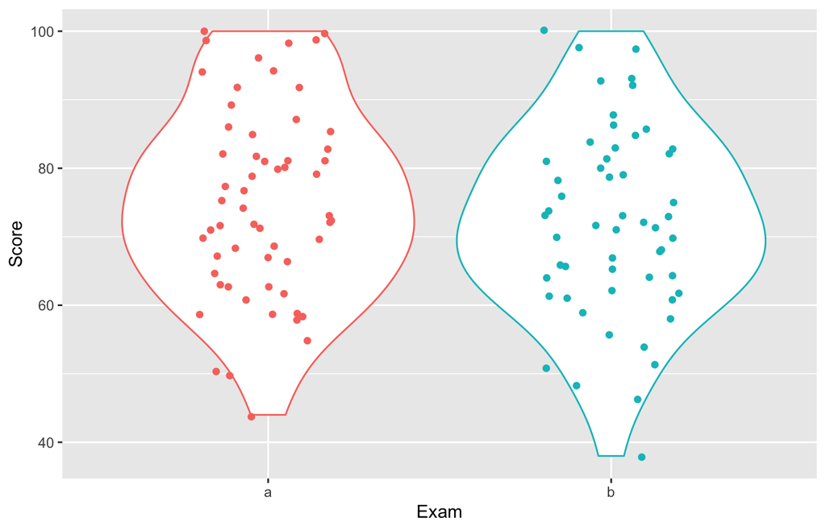

## Assumptions About the Null Hypothesis

- The shuffling process assumes the null hypothesis is true – that there is no effect of the treatment
  - In this example, the null hypothesis is that exam A and exam B are equally difficult.
  - We expect that students’ score on each exam should represent their true ability on that material – it shouldn’t matter which exam they took.

## Building a Null Distribution

- For every shuffle, we calculate the re-randomized difference in means (\(\bar{x}_A - \bar{x}_B\)).
- A distribution of these statistics gives us an idea of the variability we’d expect just by chance.

```r
null_dist <- classdata %>%
  specify(m1 ~ exam) %>%
  hypothesize(null = "independence") %>%
  generate(reps = 1000, type = "permute") %>%
  calculate(stat = "diff in means", order = c("a", "b"))
```

## Visualizing the Null Distribution

[figure not shown]

```r
null_dist %>%
  visualize()
```

## Calculating the p-value

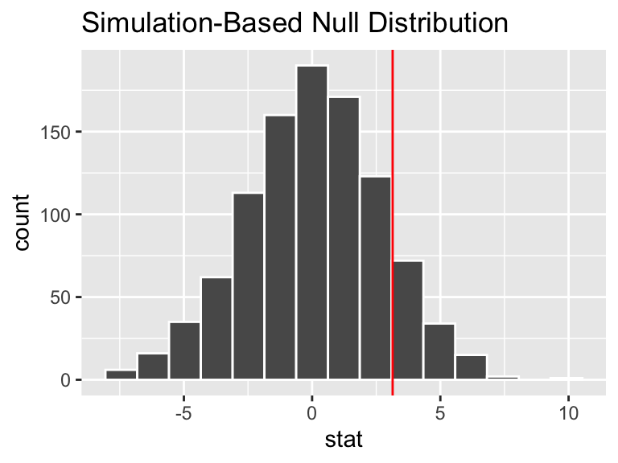

```r
obs_diff <- classdata %>%
  specify(m1 ~ exam) %>%
  calculate(stat = "diff in means", order = c("a", "b"))

null_dist %>%
  visualize() +
  geom_vline(xintercept = obs_diff, color = "red")
```

## Making a Decision

```r
null_dist %>%
  get_p_value(obs_stat = obs_diff, direction = "greater")
```

```
## # A tibble: 1 x 1
##   p_value
##     <dbl>
## 1   0.121
```

- We specified that we would use \(\alpha = 0.01\).
- Since the p-value is larger than \(\alpha\), we do not reject the null hypothesis.
- We conclude that the data do not provide convincing evidence that exam B is more difficult than exam A.